# 4.4 Array-Oriented Programming With Arrays

NumPy arrays enable the expression of many different kinds of data processing tasks as **concise array expressions that might otherwise require writing loops**

This is not totally intuitive to me...

Example: evaluate the function `sqrt(x^2 + y^2)` across a regular grid of values.

`numpy.meshgrid` takes two 1-d arrays and makes two 2-d matrices corresponding to all pairs of (x, y) in the two arrays...

```python
import numpy as np
rng = np.random.default_rng(seed=12345)

# Create 1000 equally-spaced points
points = np.arange(-5, 5, 0.01)
points.shape
```

```
(1000,)
```

```python
# Don't quite get this yet...
# 1-d array of size 1000 gets made into two 2-d arrays of size 1000 x 1000
xs, ys = np.meshgrid(points, points)
print(xs.shape)
print(ys.shape)
xs
```

```
(1000, 1000)
(1000, 1000)
```

```
array([[-5.  , -4.99, -4.98, ...,  4.97,  4.98,  4.99],
       [-5.  , -4.99, -4.98, ...,  4.97,  4.98,  4.99],
       [-5.  , -4.99, -4.98, ...,  4.97,  4.98,  4.99],
       ...,
       [-5.  , -4.99, -4.98, ...,  4.97,  4.98,  4.99],
       [-5.  , -4.99, -4.98, ...,  4.97,  4.98,  4.99],
       [-5.  , -4.99, -4.98, ...,  4.97,  4.98,  4.99]])
```

```python
ys
```

```
array([[-5.  , -5.  , -5.  , ..., -5.  , -5.  , -5.  ],
       [-4.99, -4.99, -4.99, ..., -4.99, -4.99, -4.99],
       [-4.98, -4.98, -4.98, ..., -4.98, -4.98, -4.98],
       ...,
       [ 4.97,  4.97,  4.97, ...,  4.97,  4.97,  4.97],
       [ 4.98,  4.98,  4.98, ...,  4.98,  4.98,  4.98],
       [ 4.99,  4.99,  4.99, ...,  4.99,  4.99,  4.99]])
```

```python
z = np.sqrt(xs**2 + ys**2)
z
```

```
array([[7.07106781, 7.06400028, 7.05693985, ..., 7.04988652, 7.05693985,
        7.06400028],
       [7.06400028, 7.05692568, 7.04985815, ..., 7.04279774, 7.04985815,
        7.05692568],
       [7.05693985, 7.04985815, 7.04278354, ..., 7.03571603, 7.04278354,
        7.04985815],
       ...,
       [7.04988652, 7.04279774, 7.03571603, ..., 7.0286414 , 7.03571603,
        7.04279774],
       [7.05693985, 7.04985815, 7.04278354, ..., 7.03571603, 7.04278354,
        7.04985815],
       [7.06400028, 7.05692568, 7.04985815, ..., 7.04279774, 7.04985815,
        7.05692568]])
```

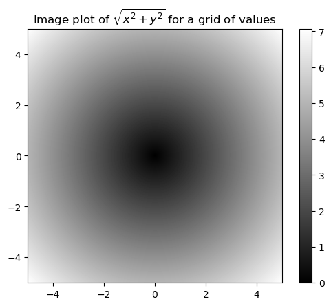

```python
import matplotlib.pyplot as plt
plt.imshow(z, cmap=plt.cm.gray, extent=[-5, 5, -5, 5])
plt.colorbar()
plt.title("Image plot of $\sqrt{x^2 + y^2}$ for a grid of values")
```

```python
plt.close("all")
```

Don't really get what we did above...

## Expressing Conditional Logic as Array Operations

Consider the expression `x if condition else y`

The function `numpy.where` is a vectorized version of this expression.

Consider the following arrays:

```python
xarr = np.array([1.1, 1.2, 1.3, 1.4, 1.5])
yarr = np.array([2.1, 2.2, 2.3, 2.4, 2.5])
cond = np.array([True, False, True, True, False])
print(xarr)
print(yarr)
print(cond)
```

```
[1.1 1.2 1.3 1.4 1.5]
[2.1 2.2 2.3 2.4 2.5]
[ True False  True  True False]
```

And imagine we want to grab from `xarr` at all the indices that `cond == True` and grab from `yarr` otherwise.

We can do this with the following list comprehension:

```python
result = [(x if c else y) for x, y, c in zip(xarr, yarr, cond)]
result
```

```
[1.1, 2.2, 1.3, 1.4, 2.5]
```

The above is slow and also only works for 1-d arrays. `where` will just match them all up and evaluate:

```python
result2 = np.where(cond, xarr, yarr)
result2
```

```
array([1.1, 2.2, 1.3, 1.4, 2.5])
```

So this is a vectorized `ifelse`? You don't have to provide arrays to the second and third arguments.

Below, we make an array, and then we replace values based on a condition (in this case positive values -> 2 and negative values -> -2)

```python
### Make an array
arr = rng.standard_normal((4, 4))
arr
```

```
array([[-1.42382504,  1.26372846, -0.87066174, -0.25917323],
       [-0.07534331, -0.74088465, -1.3677927 ,  0.6488928 ],
       [ 0.36105811, -1.95286306,  2.34740965,  0.96849691],
       [-0.75938718,  0.90219827, -0.46695317, -0.06068952]])
```

```python
### Inspect the boolean array we'll be making
arr > 0
```

[output not shown]

```python
### Evalute with where
np.where(arr > 0, 2, -2)
```

```
array([[-2,  2, -2, -2],
       [-2, -2, -2,  2],
       [ 2, -2,  2,  2],
       [-2,  2, -2, -2]])
```

```python
### Not sure why having arr instead of -2 does this. I guess it means replace the value in arr with the value in arr (i.e. do nothing) when condition is not met
np.where(arr > 0, 2, arr)
```

[output not shown]

## Mathematical and Statistical Methods

These functions compute statistics about

1. an entire array
- or -
1. the data along an axis

These are methods of the array class and also top-level numpy functions:

```python
# Make an array
arr = rng.standard_normal((5, 4))
arr
```

```
array([[ 0.78884434, -1.25666813,  0.57585751,  1.39897899],
       [ 1.32229806, -0.29969852,  0.90291934, -1.62158273],
       [-0.15818926,  0.44948393, -1.34360107, -0.08168759],
       [ 1.72473993,  2.61815943,  0.77736134,  0.8286332 ],
       [-0.95898831, -1.20938829, -1.41229201,  0.54154683]])
```

```python
# Calc mean with the method
arr.mean()
```

```
0.17933634979615845
```

```python
# Calc mean with top-lvl function
np.mean(arr)
```

```
0.17933634979615845
```

```python
# Calc sum with method
arr.sum()
```

```
3.586726995923169
```

You can also provide the axis argument to do it by rows or cols instead of the entire array:

This is confusing and is basically the opposite of what I would have expected...

```python
# Why does this give 4 values instead of 5??
# Isn't the 0-axis the rows, which we have 5 of?
# "Compute the mean down the rows"...so for every column, compute down the rows the mean?
arr.mean(axis = 0)
```

```
array([ 0.54374095,  0.06037768, -0.09995098,  0.21317774])
```

```python
# "Compute the mean down the columns"
arr.mean(axis = 1)
```

```
array([ 0.37675318,  0.07598404, -0.2834985 ,  1.48722347, -0.75978045])
```

`cumsum` and `cumprod` behave differently - they return an array of the same length with the intermediate results

```python
arr = np.array([1, 2, 3, 4, 5, 6, 7])
arr.cumsum()
```

```
array([ 1,  3,  6, 10, 15, 21, 28])
```

```python
arr.cumprod()
```

```
array([   1,    2,    6,   24,  120,  720, 5040])
```

Multi-d arrays are handled differently

```python
arr = np.array([[0, 1, 2], [3, 4, 5], [6, 7, 8]])
arr
```

```
array([[0, 1, 2],
       [3, 4, 5],
       [6, 7, 8]])
```

```python
# No axis, it flattens the array and adds
arr.cumsum()
```

```
array([ 0,  1,  3,  6, 10, 15, 21, 28, 36])
```

```python
# axis = 0
# "cumulative sum down the rows"
arr.cumsum(axis = 0)
```

```
array([[ 0,  1,  2],
       [ 3,  5,  7],
       [ 9, 12, 15]])
```

```python
# axis = 1
# "cumulative sum down the columns"
arr.cumsum(axis = 1)
```

```
array([[ 0,  1,  3],
       [ 3,  7, 12],
       [ 6, 13, 21]])
```

[figure not shown]

## Methods for Boolean Arrays

When operating on boolean arrays, `True` is converted to 1 and `False` to 0, so functions like `sum` can be used to count number of trues.

`any` is another useful function that checks if any value in the array is true (similar to length(which(x==T))>0 in R).

`all` is similar, but checks that all values are True.

```python
arr = rng.standard_normal(100)
arr
```

```
array([ 7.51939396e-01, -6.58760320e-01, -1.22867499e+00,  2.57557768e-01,
        3.12902918e-01, -1.30811690e-01,  1.26998312e+00, -9.29624577e-02,
       -6.61508890e-02, -1.10821447e+00,  1.35956851e-01,  1.34707776e+00,
        6.11440210e-02,  7.09146003e-02,  4.33654537e-01,  2.77483660e-01,
        5.30252387e-01,  5.36720969e-01,  6.18350015e-01, -7.95017456e-01,
        3.00030946e-01, -1.60270159e+00,  2.66798830e-01, -1.26162378e+00,
       -7.12708062e-02,  4.74049730e-01, -4.14853761e-01,  9.77165000e-02,
       -1.64041784e+00, -8.57258824e-01,  6.88281788e-01, -1.15452958e+00,
        6.50452389e-01, -1.38835995e+00, -9.07382457e-01, -1.09542531e+00,
        7.14569494e-03,  5.34359903e-01, -1.06580785e+00, -1.81472740e-01,
        1.62195180e+00, -3.17391946e-01, -8.15814967e-01,  3.86579017e-01,
       -2.23638926e-01, -7.01690809e-01, -1.79571318e+00,  8.18325622e-01,
       -5.71032902e-01,  7.85525063e-04, -1.06364272e+00,  1.30171450e+00,
        7.47872942e-01,  9.80875909e-01, -1.10418688e-01,  4.67918531e-01,
        8.90607150e-01,  1.02300937e+00,  3.12383389e-01, -6.19046857e-02,
       -3.59479647e-01, -7.48643984e-01, -9.65478907e-01,  3.60034657e-01,
       -2.44552532e-01, -1.99585661e+00, -1.55247617e-01,  1.06383087e+00,
       -2.75171567e-01, -1.85333593e+00, -1.24341928e-01,  7.84974522e-01,
        2.01998597e-01, -4.28074443e-01,  1.84828890e+00,  1.89995289e+00,
       -9.84250348e-02,  8.13445440e-01,  3.92494389e-01,  7.81442900e-01,
        1.45327152e+00,  8.20186045e-01,  8.77053446e-02, -6.53505648e-01,
       -8.11886879e-01, -2.55381724e-02,  1.15818454e+00,  3.00520870e-01,
        5.30566461e-02,  2.57271524e-01,  3.57428624e-02,  5.47236686e-01,
       -1.12296158e+00, -1.97524767e+00, -4.25150050e-01, -1.14907382e+00,
        1.61513805e+00, -1.58476860e-01, -2.52873345e-01, -1.53815403e+00])
```

```python
# First bit (arr > 0) converts to a boolean array
# second bit .sum() is the sum method on that array
(arr > 0).sum()
```

```
51
```

```python
(arr <= 0).sum()
```

```
49
```

Notice the () in the above examples. Those are required to call the `sum` method on the boolean array partial result. Otherwise would have to assign to a new object:

```python
bool = arr <= 0
bool
```

```
array([False,  True,  True, False, False,  True, False,  True,  True,
        True, False, False, False, False, False, False, False, False,
       False,  True, False,  True, False,  True,  True, False,  True,
       False,  True,  True, False,  True, False,  True,  True,  True,
       False, False,  True,  True, False,  True,  True, False,  True,
        True,  True, False,  True, False,  True, False, False, False,
        True, False, False, False, False,  True,  True,  True,  True,
       False,  True,  True,  True, False,  True,  True,  True, False,
       False,  True, False, False,  True, False, False, False, False,
       False, False,  True,  True,  True, False, False, False, False,
       False, False,  True,  True,  True,  True, False,  True,  True,
        True])
```

```python
bool.sum()
```

```
49
```

```python
bools = np.array([False, False, True, False])
bools.any()
```

```
True
```

```python
bools.all()
```

```
False
```

## Sorting

`sort` method will sort arrays in place (just like lists)

If you have a multi-d array, provide the axis argument to sort each 1-d array independently.

Using the function `np.sort` instead of the method returns a copy of the original array.

```python
arr = rng.standard_normal(6)
arr
```

```
array([ 0.28208603, -0.62361213,  1.12182226,  0.84122103, -0.7758961 ,
        0.41071644])
```

```python
arr.sort() # doesn't print anything b/c modified in place
arr
```

```
array([-0.7758961 , -0.62361213,  0.28208603,  0.41071644,  0.84122103,
        1.12182226])
```

```python
arr = rng.standard_normal((5, 3))
arr
```

```
array([[-0.52900707,  0.0456841 , -1.02755181],
       [-1.2292893 , -0.88335847, -0.07089346],
       [ 0.37405335, -0.02459374,  0.07726066],
       [-0.68391322, -0.72083767,  1.12062282],
       [-0.05481416, -0.08241372,  0.9359865 ]])
```

```python
# arr.sort()
# arr
```

[output not shown]

```python
# axis = 0 will sort values within each column
np.sort(arr, axis = 0)
```

```
array([[-1.2292893 , -0.88335847, -1.02755181],
       [-0.68391322, -0.72083767, -0.07089346],
       [-0.52900707, -0.08241372,  0.07726066],
       [-0.05481416, -0.02459374,  0.9359865 ],
       [ 0.37405335,  0.0456841 ,  1.12062282]])
```

```python
# axis = 1 will wort values within each row
np.sort(arr, axis = 1)
```

```
array([[-1.02755181, -0.52900707,  0.0456841 ],
       [-1.2292893 , -0.88335847, -0.07089346],
       [-0.02459374,  0.07726066,  0.37405335],
       [-0.72083767, -0.68391322,  1.12062282],
       [-0.08241372, -0.05481416,  0.9359865 ]])
```

```python
# No value defaults to -1, which sorts on the last axis, which is 1 in this case
defaultSort = np.sort(arr)
defaultSort
```

```
array([[-1.02755181, -0.52900707,  0.0456841 ],
       [-1.2292893 , -0.88335847, -0.07089346],
       [-0.02459374,  0.07726066,  0.37405335],
       [-0.72083767, -0.68391322,  1.12062282],
       [-0.08241372, -0.05481416,  0.9359865 ]])
```

```python
arr
```

```
array([[-0.52900707,  0.0456841 , -1.02755181],
       [-1.2292893 , -0.88335847, -0.07089346],
       [ 0.37405335, -0.02459374,  0.07726066],
       [-0.68391322, -0.72083767,  1.12062282],
       [-0.05481416, -0.08241372,  0.9359865 ]])
```

## Unique and Other Set Logic

Numpy has some set operations that act on 1-d arrays. They're generally faster than the base python alternatives and return arrays instead of lists.

`unique` and `in1d` are shown below, here is a table with more:

[figure not shown]

```python
# Array of names
names = np.array(["Will", "Bob", "Joe", "Bob", "Will", "Joe", "Joe"])
names
```

```
array(['Will', 'Bob', 'Joe', 'Bob', 'Will', 'Joe', 'Joe'], dtype='<U4')
```

```python
# Use unique method to retun an array
np.unique(names)
```

```
array(['Bob', 'Joe', 'Will'], dtype='<U4')
```

```python
# Default python is a list
set(names)
```

[output not shown]

```python
# Array of integers
ints = np.array([3, 3, 3, 2, 2, 1, 1, 4, 4])
np.unique(ints)
```

```
array([1, 2, 3, 4])
```

```python
# Array of values
values = np.array([6, 0, 0, 3, 2, 5, 6])
values
```

```
array([6, 0, 0, 3, 2, 5, 6])
```

```python
# Check if each element in values is in the array [2, 3, 6]
np.in1d(values, [2, 3, 6])
```

[output not shown]